# COVID-19 Severity, Hospitalization, and Mortality Rates

Here we explore adjustments to reported hospitalization, severity, and mortality rates to take data reported from China to apply to other populations with different population age structures. Adjusting in this manner allows us to estimate age-adjusted rates for other populations of interest. We can then apply these estimates to infections estimated through transmission models or other means to estimate the number of hospitalizations, severe cases, and deaths.

This adjustment makes several specific assumptions. First, we assume that variation in these rates is highly specific to age, and not other factors, and that these age-specific rates will be consistent across populations. Additionally, when applying these adjusted rates to transmission models that are not age-structured, we assume the rate of infection is the same across all ages.

```r
##'
##' Get population distribution and aggregate it to 10 year age groups
##'
##' @param country country of interest
##'
##'
get_age_pop <- function(country){

    require(stringi)
    #require(globaltoolbox)

    pop_data <- read_csv("data/WPP2019_POP.csv")
    pop_data <- pop_data %>%
        mutate(country_clean = stringi::stri_trans_general(location, "Latin-ASCII")) %>%
        filter(tolower(country_clean) == tolower(country)) %>% filter(year==max(year))

    # print for a double check
    print(pop_data$location)
    pop_data <- pop_data[,-(1:4)] %>% select(-country_clean)
    dat <- as.numeric(pop_data)
    names(dat) <- colnames(pop_data)
    return(dat)
}
```

## AGE ADJUSTMENT

Age distribution data source: https://population.un.org/wpp/Download/Standard/Population/

```r
china_agepop <- get_age_pop("China")
bangladesh_agepop <- get_age_pop("Bangladesh")
#kutupalong_agepop <- get_age_pop("Bangladesh")
```

# Estimate Hospitalization Rate

### ~ Prob Hospitalization - Total Population by Age, Reported Case-adjusted

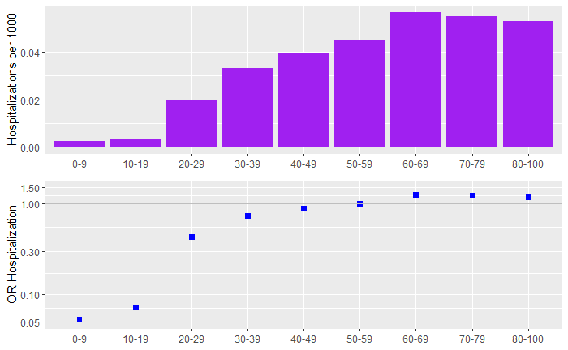

#### High Capture and Hospitalization rate scenario

Here we assume that 11% of infected individuals age 70+ years are severe following Bi et al. 2020. If we assume that 11% is equivalent to those who necessitate hospitalization, we can use this to get the age-adjusted hospitalization rate.

```r
p_hosp_china_high
```

```
[1] 0.062299
```

This seems pretty good.

#### Try again with only Hubei cases

```r
p_hosp_china_low
```

```
[1] 0.04264297
```

In this scenario, we are assuming 11% of those 70+ are severe

#### ~ Prob Hosp - CFR-adjusted

Let’s do it again but using CFR for age adjustment

```r
# double check with population structure
sum(p_inf_hosp_age * (nage_china2 / sum(nage_china2)))
```

```
[1] 0.01329745
```

This seems about right. we will use these estimates.

#### ~ Prop hospitalized - Kutupalong

Now we need to apply the population structure of Kutupalong to estimate proportion hospitalized there.

```r
pop_age <- read_csv("data/age_kutupalong.csv")
age_smooth <- smooth.spline(pop_age$mid, pop_age$tot_per_year)
pr_age <- predict(age_smooth, data.frame(mid=0:89)) %>% as.data.frame()
pr_age <- pr_age %>% rename(age=mid, prop=mid.1) %>% mutate(prop = prop / sum(pr_age$mid.1))
plot(pr_age$age, pr_age$prop)
points(pop_age$mid, pop_age$tot_per_year, col="blue", pch=20)

# Get age by 10yr groups
pr_age <- pr_age %>% mutate(age10 = floor(age/10)*10)
pr_age10 <- pr_age %>% group_by(age10) %>% summarise(pr10 = sum(prop)) %>%
    mutate(age = paste0(age10, "-", age10+9))
pr_age10_kutupalong <- as.numeric(pr_age10$pr10)
pr_age10_kutupalong[8] <- sum(pr_age10_kutupalong[8:9])
pr_age10_kutupalong <- pr_age10_kutupalong[-9]
names(pr_age10_kutupalong) <- 0:(length(pr_age10_kutupalong)-1)

# Apply to Kutupalong population structure - LOW capture
p_hosp_kutupalong_low <- sum(p_inf_hosp_age_low * pr_age10_kutupalong)
p_hosp_kutupalong_high <- sum(p_inf_hosp_age_high[1:8] * pr_age10_kutupalong)
print(p_hosp_kutupalong_low)
print(p_hosp_kutupalong_high)

p_hosp_kutupalong_low / p_hosp_china_low
p_hosp_kutupalong_high / p_hosp_china_high
```

[output not shown]